# Part 1

# EDA & Data Preprocessing on Google App Store Rating Dataset.

## Q1. Import required libraries and read the dataset

```python
import numpy as np
import pandas as pd
import matplotlib.pyplot as plt
import seaborn as sns
```

```python
df1 = pd.read_csv(r"C:\Users\USER\Desktop\New folder (2)\Apps_data+(1).csv")
```

## Q2. Check the first few samples, shape, info of the data and try to familiarize yourself with different features.

```python
# Let us look at the first 10 sample data
df1.head(10)
```

|  | App | Category | Rating | Reviews | Size | Installs | Type | Price | Content Rating | Genres | Last Updated | Current Ver | Android Ver |
| --- | --- | --- | --- | --- | --- | --- | --- | --- | --- | --- | --- | --- | --- |
| 0 | Photo Editor & Candy Camera & Grid & ScrapBook | ART_AND_DESIGN | 4.1 | 159 | 19M | 10,000+ | Free | 0 | Everyone | Art & Design | January 7, 2018 | 1.0.0 | 4.0.3 and up |
| 1 | Coloring book moana | ART_AND_DESIGN | 3.9 | 967 | 14M | 500,000+ | Free | 0 | Everyone | Art & Design;Pretend Play | January 15, 2018 | 2.0.0 | 4.0.3 and up |
| 2 | U Launcher Lite – FREE Live Cool Themes, Hide ... | ART_AND_DESIGN | 4.7 | 87510 | 8.7M | 5,000,000+ | Free | 0 | Everyone | Art & Design | August 1, 2018 | 1.2.4 | 4.0.3 and up |
| 3 | Sketch - Draw & Paint | ART_AND_DESIGN | 4.5 | 215644 | 25M | 50,000,000+ | Free | 0 | Teen | Art & Design | June 8, 2018 | Varies with device | 4.2 and up |
| 4 | Pixel Draw - Number Art Coloring Book | ART_AND_DESIGN | 4.3 | 967 | 2.8M | 100,000+ | Free | 0 | Everyone | Art & Design;Creativity | June 20, 2018 | 1.1 | 4.4 and up |
| 5 | Paper flowers instructions | ART_AND_DESIGN | 4.4 | 167 | 5.6M | 50,000+ | Free | 0 | Everyone | Art & Design | March 26, 2017 | 1.0 | 2.3 and up |
| 6 | Smoke Effect Photo Maker - Smoke Editor | ART_AND_DESIGN | 3.8 | 178 | 19M | 50,000+ | Free | 0 | Everyone | Art & Design | April 26, 2018 | 1.1 | 4.0.3 and up |
| 7 | Infinite Painter | ART_AND_DESIGN | 4.1 | 36815 | 29M | 1,000,000+ | Free | 0 | Everyone | Art & Design | June 14, 2018 | 6.1.61.1 | 4.2 and up |
| 8 | Garden Coloring Book | ART_AND_DESIGN | 4.4 | 13791 | 33M | 1,000,000+ | Free | 0 | Everyone | Art & Design | September 20, 2017 | 2.9.2 | 3.0 and up |
| 9 | Kids Paint Free - Drawing Fun | ART_AND_DESIGN | 4.7 | 121 | 3.1M | 10,000+ | Free | 0 | Everyone | Art & Design;Creativity | July 3, 2018 | 2.8 | 4.0.3 and up |

```python
# Shape of the data
df1.shape
```

```
(10841, 13)
```

```python
# Basic information about dataset and it's datatypes
df1.info()
```

```
<class 'pandas.core.frame.DataFrame'>
RangeIndex: 10841 entries, 0 to 10840
Data columns (total 13 columns):
 #   Column          Non-Null Count  Dtype
---  ------          --------------  -----
 0   App             10841 non-null  object
 1   Category        10841 non-null  object
 2   Rating          9367 non-null   float64
 3   Reviews         10841 non-null  object
 4   Size            10841 non-null  object
 5   Installs        10841 non-null  object
 6   Type            10840 non-null  object
 7   Price           10841 non-null  object
 8   Content Rating  10840 non-null  object
 9   Genres          10841 non-null  object
 10  Last Updated    10841 non-null  object
 11  Current Ver     10833 non-null  object
 12  Android Ver     10838 non-null  object
dtypes: float64(1), object(12)
memory usage: 1.1+ MB
```

## Q3. Check summary statistics of the dataset. List out the columns that need to be worked upon for model building.

```python
# Basic statistical data of numerical columns
df1.describe().round(2)
```

|  | Rating |
| --- | --- |
| count | 9367.00 |
| mean | 4.19 |
| std | 0.54 |
| min | 1.00 |
| 25% | 4.00 |
| 50% | 4.30 |
| 75% | 4.50 |
| max | 19.00 |

```python
# Basic statistical data of numerical and categorical columns
df1.describe(include = 'all').round(2)
```

|  | App | Category | Rating | Reviews | Size | Installs | Type | Price | Content Rating | Genres | Last Updated | Current Ver | Android Ver |
| --- | --- | --- | --- | --- | --- | --- | --- | --- | --- | --- | --- | --- | --- |
| count | 10841 | 10841 | 9367.00 | 10841 | 10841 | 10841 | 10840 | 10841 | 10840 | 10841 | 10841 | 10833 | 10838 |
| unique | 9660 | 34 | NaN | 6002 | 462 | 22 | 3 | 93 | 6 | 120 | 1378 | 2832 | 33 |
| top | ROBLOX | FAMILY | NaN | 0 | Varies with device | 1,000,000+ | Free | 0 | Everyone | Tools | August 3, 2018 | Varies with device | 4.1 and up |
| freq | 9 | 1972 | NaN | 596 | 1695 | 1579 | 10039 | 10040 | 8714 | 842 | 326 | 1459 | 2451 |
| mean | NaN | NaN | 4.19 | NaN | NaN | NaN | NaN | NaN | NaN | NaN | NaN | NaN | NaN |
| std | NaN | NaN | 0.54 | NaN | NaN | NaN | NaN | NaN | NaN | NaN | NaN | NaN | NaN |
| min | NaN | NaN | 1.00 | NaN | NaN | NaN | NaN | NaN | NaN | NaN | NaN | NaN | NaN |
| 25% | NaN | NaN | 4.00 | NaN | NaN | NaN | NaN | NaN | NaN | NaN | NaN | NaN | NaN |
| 50% | NaN | NaN | 4.30 | NaN | NaN | NaN | NaN | NaN | NaN | NaN | NaN | NaN | NaN |
| 75% | NaN | NaN | 4.50 | NaN | NaN | NaN | NaN | NaN | NaN | NaN | NaN | NaN | NaN |
| max | NaN | NaN | 19.00 | NaN | NaN | NaN | NaN | NaN | NaN | NaN | NaN | NaN | NaN |

The columns that needs some changes are: 1. Rating 2. Reviews 3. Size 4. Installs

## Q4. Check if there are any duplicate records in the dataset? if any drop them.

```python
# Checking the number of duplicate rows
print('The number of duplicate rows are:')
df1.duplicated().sum()
```

```
The number of duplicate rows are:
```

```
483
```

```python
# Dropping the duplicate rows permanently
df1.drop_duplicates(inplace=True)
```

```python
# Checking if they are dropped
df1.duplicated().sum()
```

```
0
```

```python
df1.shape
```

```
(10358, 13)
```

## Q5. Check the unique categories of the column 'Category', Is there any invalid category? If yes, drop them.

```python
# Looking at the unique entries of 'Category' column
list(df1['Category'].unique())
```

```
['ART_AND_DESIGN',
 'AUTO_AND_VEHICLES',
 'BEAUTY',
 'BOOKS_AND_REFERENCE',
 'BUSINESS',
 'COMICS',
 'COMMUNICATION',
 'DATING',
 'EDUCATION',
 'ENTERTAINMENT',
 'EVENTS',
 'FINANCE',
 'FOOD_AND_DRINK',
 'HEALTH_AND_FITNESS',
 'HOUSE_AND_HOME',
 'LIBRARIES_AND_DEMO',
 'LIFESTYLE',
 'GAME',
 'FAMILY',
 'MEDICAL',
 'SOCIAL',
 'SHOPPING',
 'PHOTOGRAPHY',
 'SPORTS',
 'TRAVEL_AND_LOCAL',
 'TOOLS',
 'PERSONALIZATION',
 'PRODUCTIVITY',
 'PARENTING',
 'WEATHER',
 'VIDEO_PLAYERS',
 'NEWS_AND_MAGAZINES',
 'MAPS_AND_NAVIGATION',
 '1.9']
```

```python
# Removing the category that might be invalid for our analysis
df1 = df1[df1['Category']!='1.9']
```

```python
# After removal of unwanted entry
df1['Category'].unique()
```

```
array(['ART_AND_DESIGN', 'AUTO_AND_VEHICLES', 'BEAUTY',
       'BOOKS_AND_REFERENCE', 'BUSINESS', 'COMICS', 'COMMUNICATION',
       'DATING', 'EDUCATION', 'ENTERTAINMENT', 'EVENTS', 'FINANCE',
       'FOOD_AND_DRINK', 'HEALTH_AND_FITNESS', 'HOUSE_AND_HOME',
       'LIBRARIES_AND_DEMO', 'LIFESTYLE', 'GAME', 'FAMILY', 'MEDICAL',
       'SOCIAL', 'SHOPPING', 'PHOTOGRAPHY', 'SPORTS', 'TRAVEL_AND_LOCAL',
       'TOOLS', 'PERSONALIZATION', 'PRODUCTIVITY', 'PARENTING', 'WEATHER',
       'VIDEO_PLAYERS', 'NEWS_AND_MAGAZINES', 'MAPS_AND_NAVIGATION'],
      dtype=object)
```

## Q6. Check if there are missing values present in the column Rating, If any? drop them and and create a new column as 'Rating_category' by converting ratings to high and low categories(>3.5 is high rest low)

```python
print('No of missing values in Rating column:',df1['Rating'].isna().sum())
```

```
No of missing values in Rating column: 1465
```

```python
# Drop the missing values
df1['Rating'].isnull().sum()
```

```
1465
```

```python
df1 = df1.dropna(subset='Rating')
```

```python
# New column 'Rating_Category' as 'High' for rating > 3.5 and others as 'Low'
df1['Rating_Category'] = df1['Rating'].map(lambda x : 'High' if x>3.5 else 'Low')
```

## Q7. Check the distribution of the newly created column 'Rating_category' and comment on the distribution.

```python
df1['Rating_Category'].value_counts()
```

```
Rating_Category
High    8012
Low      880
Name: count, dtype: int64
```

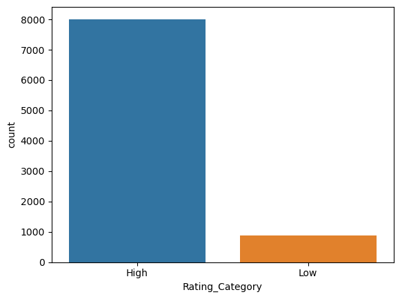

```python
sns.countplot(x = df1['Rating_Category'])
plt.show()
```

There are 8012 apps with 'High' reviews and 880 apps with 'Low' reviews.

## Q8. Convert the column "Reviews'' to numeric data type and check the presence of outliers in the column and handle the outliers using a transformation approach.(Hint: Use log transformation)

```python
# Converting 'Reviews' column to integer type data
df1['Reviews'] = df1['Reviews'].astype('int64')
```

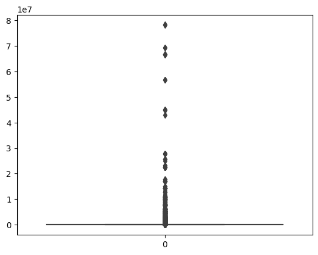

```python
# Boxplot to check for outliers
sns.boxplot(df1['Reviews'])
plt.show()
```

There seems to be considerably high number of outliers and needs to be suitably treated.

We need to drop all the zero values from the 'Reviews' column before applying log transformation since log(0) is undefined

```python
df1 = df1[df1['Reviews']!=0]
```

```python
# Log transformation to treat outliers
log = np.log(df1['Reviews'])
```

```python
log
```

```
0         5.068904
1         6.874198
2        11.379508
3        12.281384
4         6.874198
           ...
10834     1.945910
10836     3.637586
10837     1.386294
10839     4.736198
10840    12.894978
Name: Reviews, Length: 8892, dtype: float64
```

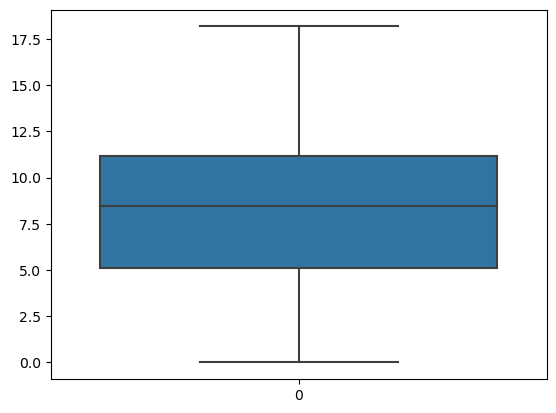

```python
# Boxplot after log transformation
sns.boxplot(log)
plt.show()
```

Outliers have been effectively treated through log transformation and all data have been narrowed down to a certain range.

## Q9. The column 'Size' contains alphanumeric values, treat the non numeric data and convert the column into suitable data type.

```python
# Replacing 'M' with six zeros and 'k' with three zeros
df1['Size'] = df1['Size'].str.replace('M', '000000')
df1['Size'] = df1['Size'].str.replace('k', '000')
```

```python
df1['Size'].head(10)
```

```
0     19000000
1     14000000
2    8.7000000
3     25000000
4    2.8000000
5    5.6000000
6     19000000
7     29000000
8     33000000
9    3.1000000
Name: Size, dtype: object
```

```python
df1 = df1[df1['Size']!= 'Varies with device']
```

```python
df1['Size'].astype('float64')
```

```
0        19000000.0
1        14000000.0
2               8.7
3        25000000.0
4               2.8
            ...
10833      619000.0
10834           2.6
10836    53000000.0
10837           3.6
10840    19000000.0
Name: Size, Length: 7424, dtype: float64
```

```python
df1.reset_index(drop=True)
```

|  | App | Category | Rating | Reviews | Size | Installs | Type | Price | Content Rating | Genres | Last Updated | Current Ver | Android Ver | Rating_Category |
| --- | --- | --- | --- | --- | --- | --- | --- | --- | --- | --- | --- | --- | --- | --- |
| 0 | Photo Editor & Candy Camera & Grid & ScrapBook | ART_AND_DESIGN | 4.1 | 159 | 19000000 | 10,000+ | Free | 0 | Everyone | Art & Design | January 7, 2018 | 1.0.0 | 4.0.3 and up | High |
| 1 | Coloring book moana | ART_AND_DESIGN | 3.9 | 967 | 14000000 | 500,000+ | Free | 0 | Everyone | Art & Design;Pretend Play | January 15, 2018 | 2.0.0 | 4.0.3 and up | High |
| 2 | U Launcher Lite – FREE Live Cool Themes, Hide ... | ART_AND_DESIGN | 4.7 | 87510 | 8.7000000 | 5,000,000+ | Free | 0 | Everyone | Art & Design | August 1, 2018 | 1.2.4 | 4.0.3 and up | High |
| 3 | Sketch - Draw & Paint | ART_AND_DESIGN | 4.5 | 215644 | 25000000 | 50,000,000+ | Free | 0 | Teen | Art & Design | June 8, 2018 | Varies with device | 4.2 and up | High |
| 4 | Pixel Draw - Number Art Coloring Book | ART_AND_DESIGN | 4.3 | 967 | 2.8000000 | 100,000+ | Free | 0 | Everyone | Art & Design;Creativity | June 20, 2018 | 1.1 | 4.4 and up | High |
| ... | ... | ... | ... | ... | ... | ... | ... | ... | ... | ... | ... | ... | ... | ... |
| 7419 | Chemin (fr) | BOOKS_AND_REFERENCE | 4.8 | 44 | 619000 | 1,000+ | Free | 0 | Everyone | Books & Reference | March 23, 2014 | 0.8 | 2.2 and up | High |
| 7420 | FR Calculator | FAMILY | 4.0 | 7 | 2.6000000 | 500+ | Free | 0 | Everyone | Education | June 18, 2017 | 1.0.0 | 4.1 and up | High |
| 7421 | Sya9a Maroc - FR | FAMILY | 4.5 | 38 | 53000000 | 5,000+ | Free | 0 | Everyone | Education | July 25, 2017 | 1.48 | 4.1 and up | High |
| 7422 | Fr. Mike Schmitz Audio Teachings | FAMILY | 5.0 | 4 | 3.6000000 | 100+ | Free | 0 | Everyone | Education | July 6, 2018 | 1.0 | 4.1 and up | High |
| 7423 | iHoroscope - 2018 Daily Horoscope & Astrology | LIFESTYLE | 4.5 | 398307 | 19000000 | 10,000,000+ | Free | 0 | Everyone | Lifestyle | July 25, 2018 | Varies with device | Varies with device | High |

7424 rows × 14 columns

## Q10. Check the column 'Installs', treat the unwanted characters and convert the column into a suitable data type.

```python
df1['Installs']
```

```
0            10,000+
1           500,000+
2         5,000,000+
3        50,000,000+
4           100,000+
            ...
10833         1,000+
10834           500+
10836         5,000+
10837           100+
10840    10,000,000+
Name: Installs, Length: 7424, dtype: object
```

```python
# '+' sign and comma(,) to be removed
df1['Installs'] = pd.to_numeric(df1['Installs'].str.replace('[+,]', '', regex= True))
```

```python
df1[['Installs']]
```

|  | Installs |
| --- | --- |
| 0 | 10000 |
| 1 | 500000 |
| 2 | 5000000 |
| 3 | 50000000 |
| 4 | 100000 |
| ... | ... |
| 10833 | 1000 |
| 10834 | 500 |
| 10836 | 5000 |
| 10837 | 100 |
| 10840 | 10000000 |

7424 rows × 1 columns

```python
# Checking the datatype
df1['Installs'].dtype
```

```
dtype('int64')
```

## Q11. Check the column 'Price' , remove the unwanted characters and convert the column into a suitable data type.

```python
df1['Price'].dtype
```

```
dtype('O')
```

```python
df1['Price'] = pd.to_numeric(df1['Price'].str.replace('$', ''))
```

```python
df1['Price'].dtype
```

```
dtype('float64')
```

```python
df1['Price'].sort_values(ascending=False)
```

```
4367     400.00
5358     399.99
5359     399.99
5362     399.99
5356     399.99
          ...
4016       0.00
4015       0.00
4014       0.00
4013       0.00
10840      0.00
Name: Price, Length: 7424, dtype: float64
```

## Q12. Drop the columns which you think redundant for the analysis.(suggestion: drop column 'rating', since we created a new feature from it (i.e. rating_category) and the columns 'App', 'Rating' ,'Genres','Last Updated', 'Current Ver','Android Ver' columns since which are redundant for our analysis)

```python
columns_drop = ['Rating', 'App', 'Rating' ,'Genres','Last Updated', 'Current Ver','Android Ver']
df1.drop(columns = columns_drop, inplace= True)
```

```python
df1
```

|  | Category | Reviews | Size | Installs | Type | Price | Content Rating | Rating_Category |
| --- | --- | --- | --- | --- | --- | --- | --- | --- |
| 0 | ART_AND_DESIGN | 159 | 19000000 | 10000 | Free | 0.0 | Everyone | High |
| 1 | ART_AND_DESIGN | 967 | 14000000 | 500000 | Free | 0.0 | Everyone | High |
| 2 | ART_AND_DESIGN | 87510 | 8.7000000 | 5000000 | Free | 0.0 | Everyone | High |
| 3 | ART_AND_DESIGN | 215644 | 25000000 | 50000000 | Free | 0.0 | Teen | High |
| 4 | ART_AND_DESIGN | 967 | 2.8000000 | 100000 | Free | 0.0 | Everyone | High |
| ... | ... | ... | ... | ... | ... | ... | ... | ... |
| 10833 | BOOKS_AND_REFERENCE | 44 | 619000 | 1000 | Free | 0.0 | Everyone | High |
| 10834 | FAMILY | 7 | 2.6000000 | 500 | Free | 0.0 | Everyone | High |
| 10836 | FAMILY | 38 | 53000000 | 5000 | Free | 0.0 | Everyone | High |
| 10837 | FAMILY | 4 | 3.6000000 | 100 | Free | 0.0 | Everyone | High |
| 10840 | LIFESTYLE | 398307 | 19000000 | 10000000 | Free | 0.0 | Everyone | High |

7424 rows × 8 columns

## Q13. Encode the categorical columns.

```python
# Get info of all columns to see categorical columns
df1.info()
```

```
<class 'pandas.core.frame.DataFrame'>
Index: 7424 entries, 0 to 10840
Data columns (total 8 columns):
 #   Column           Non-Null Count  Dtype
---  ------           --------------  -----
 0   Category         7424 non-null   object
 1   Reviews          7424 non-null   int64
 2   Size             7424 non-null   object
 3   Installs         7424 non-null   int64
 4   Type             7424 non-null   object
 5   Price            7424 non-null   float64
 6   Content Rating   7424 non-null   object
 7   Rating_Category  7424 non-null   object
dtypes: float64(1), int64(2), object(5)
memory usage: 522.0+ KB
```

We find four columns that can be encoded 1. Category 2. Type 3. Content Rating 4. Rating_Category

### Let us use Label Encoding - It assigns a unique number to each category of a column to make it easier for the machine to understand the data.

```python
# Import the necessary libraries
from sklearn.preprocessing import LabelEncoder
```

```python
labelencoder = LabelEncoder()
```

##### 1. Category

```python
# Check for the categories of the column 'Category'
print(df1['Category'].unique())
```

```
['ART_AND_DESIGN' 'AUTO_AND_VEHICLES' 'BEAUTY' 'BOOKS_AND_REFERENCE'
 'BUSINESS' 'COMICS' 'COMMUNICATION' 'DATING' 'EDUCATION' 'ENTERTAINMENT'
 'EVENTS' 'FINANCE' 'FOOD_AND_DRINK' 'HEALTH_AND_FITNESS' 'HOUSE_AND_HOME'
 'LIBRARIES_AND_DEMO' 'LIFESTYLE' 'GAME' 'FAMILY' 'MEDICAL' 'SOCIAL'
 'SHOPPING' 'PHOTOGRAPHY' 'SPORTS' 'TRAVEL_AND_LOCAL' 'TOOLS'
 'PERSONALIZATION' 'PRODUCTIVITY' 'PARENTING' 'WEATHER' 'VIDEO_PLAYERS'
 'NEWS_AND_MAGAZINES' 'MAPS_AND_NAVIGATION']
```

```python
print('No of unique categories :',df1['Category'].nunique())
```

```
No of unique categories : 33
```

```python
# Transform 'Category' using label encoding
df1['Category'] = labelencoder.fit_transform(df1['Category'])
```

```python
# After label encoding
df1['Category'].value_counts()
```

```
Category
11    1591
14     959
29     634
23     279
20     277
18     273
12     263
28     232
25     231
4      225
24     225
6      206
15     199
27     170
```

[output cut: 20 more lines]

### 2. Type

```python
df1['Type'].unique()
```

```
array(['Free', 'Paid'], dtype=object)
```

```python
df1['Type'] = labelencoder.fit_transform(df1['Type'])
```

```python
df1.head()
```

|  | Category | Reviews | Size | Installs | Type | Price | Content Rating | Rating_Category |
| --- | --- | --- | --- | --- | --- | --- | --- | --- |
| 0 | 0 | 159 | 19000000 | 10000 | 0 | 0.0 | Everyone | High |
| 1 | 0 | 967 | 14000000 | 500000 | 0 | 0.0 | Everyone | High |
| 2 | 0 | 87510 | 8.7000000 | 5000000 | 0 | 0.0 | Everyone | High |
| 3 | 0 | 215644 | 25000000 | 50000000 | 0 | 0.0 | Teen | High |
| 4 | 0 | 967 | 2.8000000 | 100000 | 0 | 0.0 | Everyone | High |

```python
df1['Type'].value_counts()
```

```
Type
0    6877
1     547
Name: count, dtype: int64
```

### 3. Content Rating

```python
# Check for the categories of the column 'Content Rating'
df1['Content Rating'].unique()
```

```
array(['Everyone', 'Teen', 'Everyone 10+', 'Mature 17+',
       'Adults only 18+', 'Unrated'], dtype=object)
```

```python
df1['Content Rating'].nunique()
```

```
6
```

```python
df1['Content Rating'] = labelencoder.fit_transform(df1['Content Rating'])
```

```python
df1.head()
```

|  | Category | Reviews | Size | Installs | Type | Price | Content Rating | Rating_Category |
| --- | --- | --- | --- | --- | --- | --- | --- | --- |
| 0 | 0 | 159 | 19000000 | 10000 | 0 | 0.0 | 1 | High |
| 1 | 0 | 967 | 14000000 | 500000 | 0 | 0.0 | 1 | High |
| 2 | 0 | 87510 | 8.7000000 | 5000000 | 0 | 0.0 | 1 | High |
| 3 | 0 | 215644 | 25000000 | 50000000 | 0 | 0.0 | 4 | High |
| 4 | 0 | 967 | 2.8000000 | 100000 | 0 | 0.0 | 1 | High |

```python
df1['Content Rating'].value_counts()
```

```
Content Rating
1    5958
4     832
3     332
2     299
0       2
5       1
Name: count, dtype: int64
```

### 4. Rating Category

```python
df1['Rating_Category'].unique()
```

```
array(['High', 'Low'], dtype=object)
```

```python
df1['Rating_Category'] = labelencoder.fit_transform(df1['Rating_Category'])
```

```python
df1.head()
```

|  | Category | Reviews | Size | Installs | Type | Price | Content Rating | Rating_Category |
| --- | --- | --- | --- | --- | --- | --- | --- | --- |
| 0 | 0 | 159 | 19000000 | 10000 | 0 | 0.0 | 1 | 0 |
| 1 | 0 | 967 | 14000000 | 500000 | 0 | 0.0 | 1 | 0 |
| 2 | 0 | 87510 | 8.7000000 | 5000000 | 0 | 0.0 | 1 | 0 |
| 3 | 0 | 215644 | 25000000 | 50000000 | 0 | 0.0 | 4 | 0 |
| 4 | 0 | 967 | 2.8000000 | 100000 | 0 | 0.0 | 1 | 0 |

```python
df1['Rating_Category'].value_counts()
```

```
Rating_Category
0    6599
1     825
Name: count, dtype: int64
```

## Q14. Segregate the target and independent features (Hint: Use Rating_category as the target)

```python
# We have to use 'Rating_Category' as the target

X = df1.drop('Rating_Category', axis = 1)  # Independent variable

Y = df1[['Rating_Category']]   # Dependent variable
```

```python
X
```

|  | Category | Reviews | Size | Installs | Type | Price | Content Rating |
| --- | --- | --- | --- | --- | --- | --- | --- |
| 0 | 0 | 159 | 19000000 | 10000 | 0 | 0.0 | 1 |
| 1 | 0 | 967 | 14000000 | 500000 | 0 | 0.0 | 1 |
| 2 | 0 | 87510 | 8.7000000 | 5000000 | 0 | 0.0 | 1 |
| 3 | 0 | 215644 | 25000000 | 50000000 | 0 | 0.0 | 4 |
| 4 | 0 | 967 | 2.8000000 | 100000 | 0 | 0.0 | 1 |
| ... | ... | ... | ... | ... | ... | ... | ... |
| 10833 | 3 | 44 | 619000 | 1000 | 0 | 0.0 | 1 |
| 10834 | 11 | 7 | 2.6000000 | 500 | 0 | 0.0 | 1 |
| 10836 | 11 | 38 | 53000000 | 5000 | 0 | 0.0 | 1 |
| 10837 | 11 | 4 | 3.6000000 | 100 | 0 | 0.0 | 1 |
| 10840 | 18 | 398307 | 19000000 | 10000000 | 0 | 0.0 | 1 |

7424 rows × 7 columns

```python
Y
```

|  | Rating_Category |
| --- | --- |
| 0 | 0 |
| 1 | 0 |
| 2 | 0 |
| 3 | 0 |
| 4 | 0 |
| ... | ... |
| 10833 | 0 |
| 10834 | 0 |
| 10836 | 0 |
| 10837 | 0 |
| 10840 | 0 |

7424 rows × 1 columns

## Q15. Split the dataset into train and test.

```python
# Import the necesary libraries
from sklearn.model_selection import train_test_split
```

```python
# Let us split the model into train and test
X_train, X_test, Y_train, Y_test = train_test_split(X, Y, test_size= 0.20, random_state=10)
```

```python
X_train
```

|  | Category | Reviews | Size | Installs | Type | Price | Content Rating |
| --- | --- | --- | --- | --- | --- | --- | --- |
| 7899 | 20 | 12 | 44000000 | 100 | 1 | 6.99 | 1 |
| 6961 | 15 | 3 | 2.4000000 | 1000 | 0 | 0.00 | 1 |
| 9079 | 11 | 152 | 1.2000000 | 10000 | 0 | 0.00 | 1 |
| 3978 | 23 | 8 | 4.5000000 | 1000 | 0 | 0.00 | 1 |
| 21 | 0 | 654 | 12000000 | 100000 | 0 | 0.00 | 1 |
| ... | ... | ... | ... | ... | ... | ... | ... |
| 5258 | 0 | 18 | 3.6000000 | 1000 | 0 | 0.00 | 1 |
| 2095 | 11 | 530904 | 51000000 | 10000000 | 0 | 0.00 | 1 |
| 6926 | 11 | 11 | 9.4000000 | 1000 | 0 | 0.00 | 1 |
| 10632 | 11 | 87 | 5.4000000 | 5000 | 0 | 0.00 | 1 |
| 2027 | 11 | 11436 | 15000000 | 1000000 | 0 | 0.00 | 1 |

5939 rows × 7 columns

```python
X_test
```

|  | Category | Reviews | Size | Installs | Type | Price | Content Rating |
| --- | --- | --- | --- | --- | --- | --- | --- |
| 4950 | 29 | 14491 | 4.3000000 | 1000000 | 0 | 0.00 | 1 |
| 8686 | 23 | 293 | 3.4000000 | 100000 | 0 | 0.00 | 1 |
| 5941 | 29 | 8 | 6.7000000 | 1000 | 0 | 0.00 | 1 |
| 7621 | 14 | 14563 | 74000000 | 1000000 | 0 | 0.00 | 2 |
| 7412 | 11 | 145 | 14000000 | 10000 | 0 | 0.00 | 1 |
| ... | ... | ... | ... | ... | ... | ... | ... |
| 26 | 0 | 20260 | 25000000 | 500000 | 0 | 0.00 | 1 |
| 3341 | 29 | 428581 | 4.7000000 | 10000000 | 0 | 0.00 | 1 |
| 10174 | 14 | 33 | 71000000 | 5000 | 0 | 0.00 | 4 |
| 10373 | 4 | 6 | 7.7000000 | 1000 | 0 | 0.00 | 1 |
| 10682 | 14 | 85468 | 36000000 | 1000000 | 1 | 0.99 | 1 |

1485 rows × 7 columns

```python
Y_train
```

|  | Rating_Category |
| --- | --- |
| 7899 | 0 |
| 6961 | 1 |
| 9079 | 0 |
| 3978 | 0 |
| 21 | 0 |
| ... | ... |
| 5258 | 0 |
| 2095 | 0 |
| 6926 | 0 |
| 10632 | 0 |
| 2027 | 0 |

5939 rows × 1 columns

```python
Y_test
```

|  | Rating_Category |
| --- | --- |
| 4950 | 0 |
| 8686 | 0 |
| 5941 | 1 |
| 7621 | 0 |
| 7412 | 0 |
| ... | ... |
| 26 | 0 |
| 3341 | 0 |
| 10174 | 0 |
| 10373 | 0 |
| 10682 | 0 |

1485 rows × 1 columns

## Q16. Standardize the data, so that the values are within a particular range.

```python
#Importing necessary libraries.
from sklearn.preprocessing import StandardScaler
```

```python
scaler = StandardScaler()
```

```python
df1.info()
```

```
<class 'pandas.core.frame.DataFrame'>
Index: 7424 entries, 0 to 10840
Data columns (total 8 columns):
 #   Column           Non-Null Count  Dtype
---  ------           --------------  -----
 0   Category         7424 non-null   int32
 1   Reviews          7424 non-null   int64
 2   Size             7424 non-null   object
 3   Installs         7424 non-null   int64
 4   Type             7424 non-null   int32
 5   Price            7424 non-null   float64
 6   Content Rating   7424 non-null   int32
 7   Rating_Category  7424 non-null   int32
dtypes: float64(1), int32(4), int64(2), object(1)
memory usage: 406.0+ KB
```

```python
# Standardizing
df1 = scaler.fit_transform(df1)
```

```python
pd.DataFrame(df1)
```

|  | 0 | 1 | 2 | 3 | 4 | 5 | 6 | 7 |
| --- | --- | --- | --- | --- | --- | --- | --- | --- |
| 0 | -2.037666 | -0.159802 | -0.074223 | -0.168764 | -0.282029 | -0.063058 | -0.463220 | -0.35358 |
| 1 | -2.037666 | -0.159338 | -0.274991 | -0.158181 | -0.282029 | -0.063058 | -0.463220 | -0.35358 |
| 2 | -2.037666 | -0.109701 | -0.837140 | -0.060990 | -0.282029 | -0.063058 | -0.463220 | -0.35358 |
| 3 | -2.037666 | -0.036209 | 0.166698 | 0.910911 | -0.282029 | -0.063058 | 2.517665 | -0.35358 |
| 4 | -2.037666 | -0.159338 | -0.837140 | -0.166820 | -0.282029 | -0.063058 | -0.463220 | -0.35358 |
| ... | ... | ... | ... | ... | ... | ... | ... | ... |
| 7419 | -1.669089 | -0.159868 | -0.812285 | -0.168958 | -0.282029 | -0.063058 | -0.463220 | -0.35358 |
| 7420 | -0.686217 | -0.159889 | -0.837140 | -0.168969 | -0.282029 | -0.063058 | -0.463220 | -0.35358 |
| 7421 | -0.686217 | -0.159871 | 1.290997 | -0.168872 | -0.282029 | -0.063058 | -0.463220 | -0.35358 |
| 7422 | -0.686217 | -0.159891 | -0.837140 | -0.168977 | -0.282029 | -0.063058 | -0.463220 | -0.35358 |
| 7423 | 0.173797 | 0.068559 | -0.074223 | 0.046999 | -0.282029 | -0.063058 | -0.463220 | -0.35358 |

7424 rows × 8 columns

# End of Part 1

# PART II: Data Visualization on Honey Production dataset using seaborn and matplotlib libraries.

## Q1. Import required libraries and read the dataset.

```python
import numpy as np
import pandas as pd
import matplotlib.pyplot as plt
import seaborn as sns
```

```python
df2 = pd.read_csv(r"C:\Users\USER\Desktop\New folder (2)\honeyproduction.csv")
```

## Q2. Check the first few samples, shape, info of the data and try to familiarize yourself with different features.

```python
df2.head()
```

|  | state | numcol | yieldpercol | totalprod | stocks | priceperlb | prodvalue | year |
| --- | --- | --- | --- | --- | --- | --- | --- | --- |
| 0 | AL | 16000.0 | 71 | 1136000.0 | 159000.0 | 0.72 | 818000.0 | 1998 |
| 1 | AZ | 55000.0 | 60 | 3300000.0 | 1485000.0 | 0.64 | 2112000.0 | 1998 |
| 2 | AR | 53000.0 | 65 | 3445000.0 | 1688000.0 | 0.59 | 2033000.0 | 1998 |
| 3 | CA | 450000.0 | 83 | 37350000.0 | 12326000.0 | 0.62 | 23157000.0 | 1998 |
| 4 | CO | 27000.0 | 72 | 1944000.0 | 1594000.0 | 0.70 | 1361000.0 | 1998 |

```python
df2.shape
```

```
(626, 8)
```

```python
df2.info()
```

```
<class 'pandas.core.frame.DataFrame'>
RangeIndex: 626 entries, 0 to 625
Data columns (total 8 columns):
 #   Column       Non-Null Count  Dtype
---  ------       --------------  -----
 0   state        626 non-null    object
 1   numcol       626 non-null    float64
 2   yieldpercol  626 non-null    int64
 3   totalprod    626 non-null    float64
 4   stocks       626 non-null    float64
 5   priceperlb   626 non-null    float64
 6   prodvalue    626 non-null    float64
 7   year         626 non-null    int64
dtypes: float64(5), int64(2), object(1)
memory usage: 39.3+ KB
```

```python
df2.isnull().sum()
```

```
state          0
numcol         0
yieldpercol    0
totalprod      0
stocks         0
priceperlb     0
prodvalue      0
year           0
dtype: int64
```

## Q3. Display the percentage distribution of the data in each year using the pie chart.

```python
pie_year = df2['year'].value_counts()
```

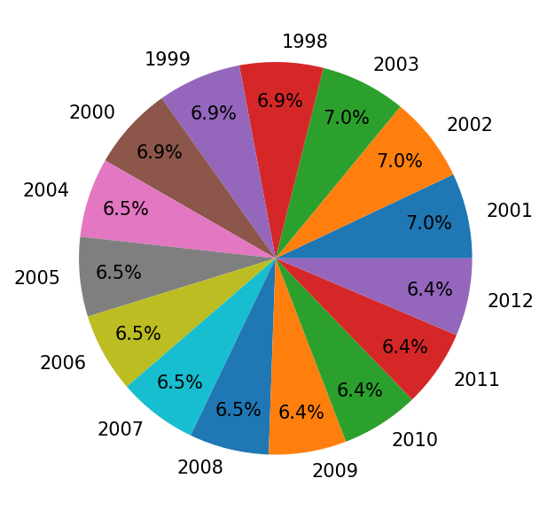

```python
plt.figure(dpi=150)
plt.pie(pie_year, autopct= '%.1f%%', labels= pie_year.index, pctdistance = 0.8)
plt.show()
```

## Q4. Plot and Understand the distribution of the variable "price per lb" using displot, and write your findings.

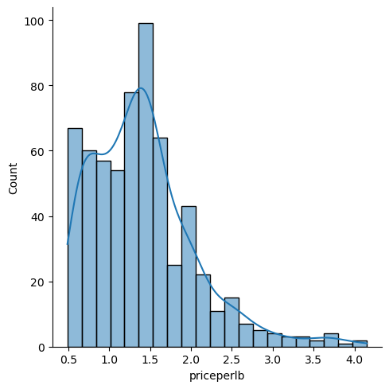

```python
plt.figure(figsize=(7,5), dpi=300)
sns.displot(x = df2['priceperlb'], kde= True)
plt.show()
```

The data is right-tailed which means it is positively skewed. Mean > Median

## Q5. Plot and understand the relationship between the variables 'numcol' and 'prodval' through scatterplot, and write your findings.

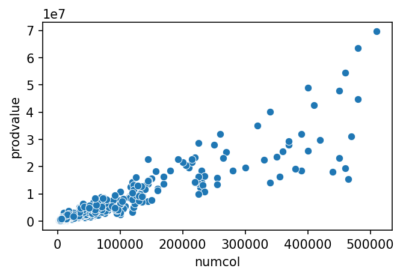

```python
plt.figure(figsize=(5,3), dpi=150)
sns.scatterplot(x = df2['numcol'], y = df2['prodvalue'])
plt.show()
```

## Q6. Plot and understand the relationship between categorical variable 'year' and a numerical variable 'prodvalue' through boxplot, and write your findings.

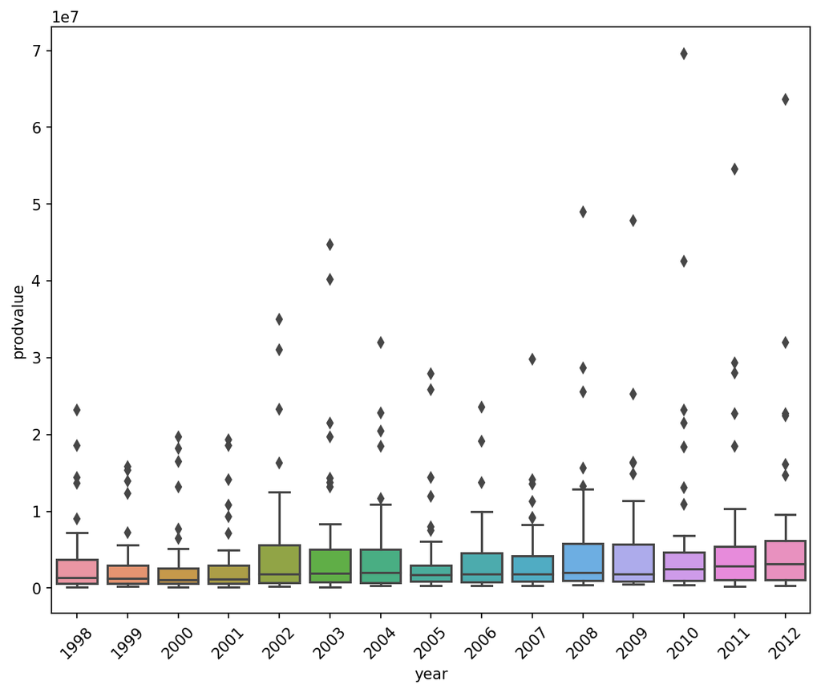

```python
plt.figure(figsize=(9,7), dpi=150)
sns.boxplot(x = df2['year'], y = df2['prodvalue'])
plt.xticks(rotation  = 45)
plt.show()
```

## Q7. Visualize and understand the relationship between the multiple pairs of variables throughout different years using pairplot and add your inferences. (use columns 'numcol', 'yield percol', 'total prod', 'prodvalue','year')

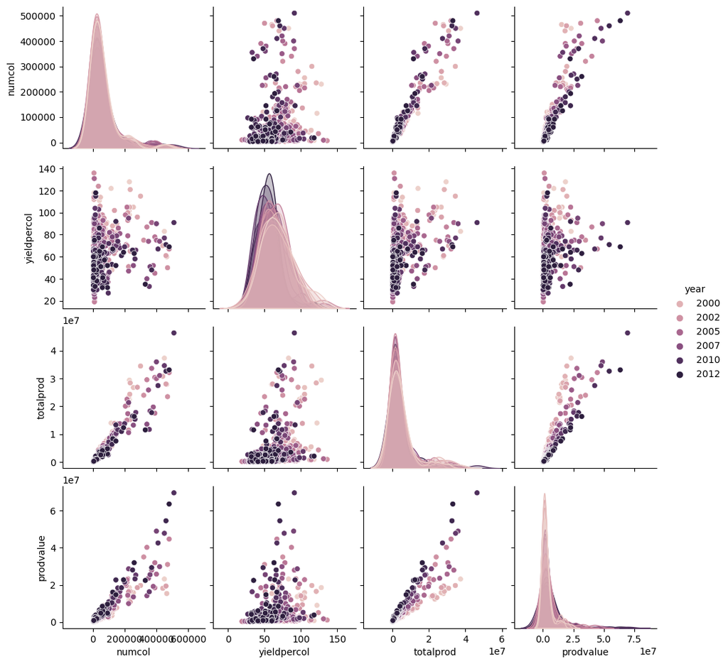

```python
columns = ['numcol', 'yieldpercol', 'totalprod', 'prodvalue','year']
sns.pairplot(df2[columns], hue = 'year')
plt.show()
```

## Q8. Display the correlation values using a plot and add your inferences. (use columns 'numcol', 'yield percol', 'total prod', 'stocks', 'price per lb', 'prodvalue')

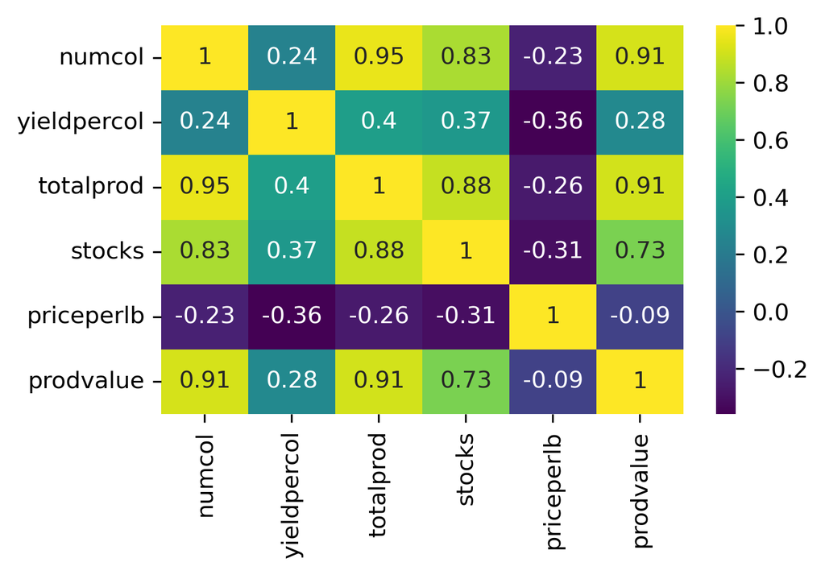

```python
plt.figure(figsize=(5,3), dpi=300)
columns = ['numcol', 'yieldpercol', 'totalprod', 'stocks', 'priceperlb', 'prodvalue']
corr_matrix  = df2[columns].corr()
sns.heatmap(corr_matrix, annot= True, cmap = 'viridis')
```

# End of Part 2